# 五王之战分析 - 冰与火之歌

## 简介

五王之战（War of the Five Kings）是著名严肃奇幻小说《冰与火之歌》中的著名内战。这是一场规模空前、波及七大王国的内乱。顾名思义，前后共有五人在战争中称王：乔佛里、史坦尼斯、蓝礼均声称自己是铁王座的合法继承人。除此之外，罗柏·史塔克被北境众封臣推选为北境之王，巴隆·葛雷乔伊亦再度掀起独立大旗，欲摆脱铁王座的统治，自称为铁群岛之王。

本数据集(battles.csv)包含了五王之战期间的战争，它是所有战斗的大集合。该数据是Kaggle中[Game of Thrones](https://www.kaggle.com/mylesoneill/game-of-thrones)的一部分。

数据中的变量含义解释：

```
name: 战争的名称，字符变量。
year: 战争发生的年份，数值变量。
battle_number: 本数据中的unique id，对应每一场独立的战役，数值变量。
attacker_king: 攻击方的国王，"/"表示了国王的更换。例如："Joffrey/Tommen Baratheon"意味着Tomen Baratheon继承了Joffrey的王位，分类变量。
defender_king: 防守方的国王，分类变量。
attacker_1: 攻击方将领，字符变量。
attacker_2: 攻击方将领，字符变量。
attacker_3: 攻击方将领，字符变量。
attacker_4: 攻击方将领，字符变量。
defender_1: 防守方将领，字符变量。
defender_2: 防守方将领，字符变量。
defender_3: 防守方将领，字符变量。
defender_4: 防守方将领，字符变量。
attacker_outcome: 从攻击方角度来看的战争结果，分别有：win, loss, draw，分类变量。
battle_type: 战争的类别。pitched_battle: 双方军队在一个地点相遇并战斗，这也是最基本的战争类别；ambush: 以隐身或诡计为主要攻击手段的战争；siege: 阵地战；razing: 对未设防位置的攻击。分类变量。
major_death: 是否有重要人物的死亡，二进制变量。
major_capture: 是否有重要人物的被捕，二进制变量。
attacker_size: 攻击方力量的大小，并未对骑兵、步兵等士兵种类有所区分，数值变量。
defender_size: 防守方力量的大小，并未对骑兵、步兵等士兵种类有所区分，数值变量。
attacker_commander: 攻击方的主要指挥官。指挥官的名字中并没有包含头衔，不同的指挥官名字用逗号隔开，字符变量。
defender_commander: 防守方的主要指挥官。指挥官的名字中并没有包含头衔，不同的指挥官名字用逗号隔开，字符变量。
summer: 战争是否发生于夏天，二进制变量。
location: 战争发生的地点，字符变量。
region: 战争发生的地域，包括：Beyond the Wall, The North, The Iron Islands, The Riverlands, The Vale of Arryn, The Westerlands, The Crownlands, The Reach, The Stormlands, Dorne，分类变量。
note: 注释，字符变量。
```

## 提出问题

**1.战争主要发生在何时、何地、何方？**

**2.影响战争胜负的因素有那些？如发起方、战争类型、参战人数等。**

## 数据评估和清理

```python
# TO DO: load pacakges
import numpy as np
import pandas as pd
import matplotlib.pyplot as plt
%matplotlib inline
```

```python
# TO DO: load the dataset
df = pd.read_csv('battles.csv')
```

```python
# TO DO: check the dataset general info
df.head()
```

|  | name | year | battle_number | attacker_king | defender_king | attacker_1 | attacker_2 | attacker_3 | attacker_4 | defender_1 | ... | major_death | major_capture | attacker_size | defender_size | attacker_commander | defender_commander | summer | location | region | note |
| --- | --- | --- | --- | --- | --- | --- | --- | --- | --- | --- | --- | --- | --- | --- | --- | --- | --- | --- | --- | --- | --- |
| 0 | Battle of the Golden Tooth | 298 | 1 | Joffrey/Tommen Baratheon | Robb Stark | Lannister | NaN | NaN | NaN | Tully | ... | 1.0 | 0.0 | 15000.0 | 4000.0 | Jaime Lannister | Clement Piper, Vance | 1.0 | Golden Tooth | The Westerlands | NaN |
| 1 | Battle at the Mummer's Ford | 298 | 2 | Joffrey/Tommen Baratheon | Robb Stark | Lannister | NaN | NaN | NaN | Baratheon | ... | 1.0 | 0.0 | NaN | 120.0 | Gregor Clegane | Beric Dondarrion | 1.0 | Mummer's Ford | The Riverlands | NaN |
| 2 | Battle of Riverrun | 298 | 3 | Joffrey/Tommen Baratheon | Robb Stark | Lannister | NaN | NaN | NaN | Tully | ... | 0.0 | 1.0 | 15000.0 | 10000.0 | Jaime Lannister, Andros Brax | Edmure Tully, Tytos Blackwood | 1.0 | Riverrun | The Riverlands | NaN |
| 3 | Battle of the Green Fork | 298 | 4 | Robb Stark | Joffrey/Tommen Baratheon | Stark | NaN | NaN | NaN | Lannister | ... | 1.0 | 1.0 | 18000.0 | 20000.0 | Roose Bolton, Wylis Manderly, Medger Cerwyn, H... | Tywin Lannister, Gregor Clegane, Kevan Lannist... | 1.0 | Green Fork | The Riverlands | NaN |
| 4 | Battle of the Whispering Wood | 298 | 5 | Robb Stark | Joffrey/Tommen Baratheon | Stark | Tully | NaN | NaN | Lannister | ... | 1.0 | 1.0 | 1875.0 | 6000.0 | Robb Stark, Brynden Tully | Jaime Lannister | 1.0 | Whispering Wood | The Riverlands | NaN |

5 rows × 25 columns

```python
df.tail()
```

|  | name | year | battle_number | attacker_king | defender_king | attacker_1 | attacker_2 | attacker_3 | attacker_4 | defender_1 | ... | major_death | major_capture | attacker_size | defender_size | attacker_commander | defender_commander | summer | location | region | note |
| --- | --- | --- | --- | --- | --- | --- | --- | --- | --- | --- | --- | --- | --- | --- | --- | --- | --- | --- | --- | --- | --- |
| 33 | Second Seige of Storm's End | 300 | 34 | Joffrey/Tommen Baratheon | Stannis Baratheon | Baratheon | NaN | NaN | NaN | Baratheon | ... | 0.0 | 0.0 | NaN | 200.0 | Mace Tyrell, Mathis Rowan | Gilbert Farring | 0.0 | Storm's End | The Stormlands | NaN |
| 34 | Siege of Dragonstone | 300 | 35 | Joffrey/Tommen Baratheon | Stannis Baratheon | Baratheon | NaN | NaN | NaN | Baratheon | ... | 0.0 | 0.0 | 2000.0 | NaN | Loras Tyrell, Raxter Redwyne | Rolland Storm | 0.0 | Dragonstone | The Stormlands | NaN |
| 35 | Siege of Riverrun | 300 | 36 | Joffrey/Tommen Baratheon | Robb Stark | Lannister | Frey | NaN | NaN | Tully | ... | 0.0 | 0.0 | 3000.0 | NaN | Daven Lannister, Ryman Fey, Jaime Lannister | Brynden Tully | 0.0 | Riverrun | The Riverlands | NaN |
| 36 | Siege of Raventree | 300 | 37 | Joffrey/Tommen Baratheon | Robb Stark | Bracken | Lannister | NaN | NaN | Blackwood | ... | 0.0 | 1.0 | 1500.0 | NaN | Jonos Bracken, Jaime Lannister | Tytos Blackwood | 0.0 | Raventree | The Riverlands | NaN |
| 37 | Siege of Winterfell | 300 | 38 | Stannis Baratheon | Joffrey/Tommen Baratheon | Baratheon | Karstark | Mormont | Glover | Bolton | ... | NaN | NaN | 5000.0 | 8000.0 | Stannis Baratheon | Roose Bolton | 0.0 | Winterfell | The North | NaN |

5 rows × 25 columns

```python
df.info()
df.describe()
```

```
<class 'pandas.core.frame.DataFrame'>
RangeIndex: 38 entries, 0 to 37
Data columns (total 25 columns):
name                  38 non-null object
year                  38 non-null int64
battle_number         38 non-null int64
attacker_king         36 non-null object
defender_king         35 non-null object
attacker_1            38 non-null object
attacker_2            10 non-null object
attacker_3            3 non-null object
attacker_4            2 non-null object
defender_1            37 non-null object
defender_2            2 non-null object
defender_3            0 non-null float64
defender_4            0 non-null float64
attacker_outcome      37 non-null object
battle_type           37 non-null object
major_death           37 non-null float64
major_capture         37 non-null float64
attacker_size         24 non-null float64
defender_size         19 non-null float64
attacker_commander    37 non-null object
defender_commander    28 non-null object
summer                37 non-null float64
location              37 non-null object
region                38 non-null object
note                  5 non-null object
dtypes: float64(7), int64(2), object(16)
memory usage: 7.5+ KB
```

|  | year | battle_number | defender_3 | defender_4 | major_death | major_capture | attacker_size | defender_size | summer |
| --- | --- | --- | --- | --- | --- | --- | --- | --- | --- |
| count | 38.000000 | 38.000000 | 0.0 | 0.0 | 37.000000 | 37.000000 | 24.000000 | 19.000000 | 37.000000 |
| mean | 299.105263 | 19.500000 | NaN | NaN | 0.351351 | 0.297297 | 9942.541667 | 6428.157895 | 0.702703 |
| std | 0.689280 | 11.113055 | NaN | NaN | 0.483978 | 0.463373 | 20283.092065 | 6225.182106 | 0.463373 |
| min | 298.000000 | 1.000000 | NaN | NaN | 0.000000 | 0.000000 | 20.000000 | 100.000000 | 0.000000 |
| 25% | 299.000000 | 10.250000 | NaN | NaN | 0.000000 | 0.000000 | 1375.000000 | 1070.000000 | 0.000000 |
| 50% | 299.000000 | 19.500000 | NaN | NaN | 0.000000 | 0.000000 | 4000.000000 | 6000.000000 | 1.000000 |
| 75% | 300.000000 | 28.750000 | NaN | NaN | 1.000000 | 1.000000 | 8250.000000 | 10000.000000 | 1.000000 |
| max | 300.000000 | 38.000000 | NaN | NaN | 1.000000 | 1.000000 | 100000.000000 | 20000.000000 | 1.000000 |

```python
# TO DO: clean the data (optional: only there are problems)
# 检查重复数据
sum(df.duplicated())
```

```
0
```

```python
#删除数据缺失较多的列
df.drop(['attacker_3', 'attacker_4', 'defender_3', 'defender_4', 'note'], axis = 1, inplace = True)
```

```python
df.head()
```

|  | name | year | battle_number | attacker_king | defender_king | attacker_1 | attacker_2 | defender_1 | defender_2 | attacker_outcome | battle_type | major_death | major_capture | attacker_size | defender_size | attacker_commander | defender_commander | summer | location | region |
| --- | --- | --- | --- | --- | --- | --- | --- | --- | --- | --- | --- | --- | --- | --- | --- | --- | --- | --- | --- | --- |
| 0 | Battle of the Golden Tooth | 298 | 1 | Joffrey/Tommen Baratheon | Robb Stark | Lannister | NaN | Tully | NaN | win | pitched battle | 1.0 | 0.0 | 15000.0 | 4000.0 | Jaime Lannister | Clement Piper, Vance | 1.0 | Golden Tooth | The Westerlands |
| 1 | Battle at the Mummer's Ford | 298 | 2 | Joffrey/Tommen Baratheon | Robb Stark | Lannister | NaN | Baratheon | NaN | win | ambush | 1.0 | 0.0 | NaN | 120.0 | Gregor Clegane | Beric Dondarrion | 1.0 | Mummer's Ford | The Riverlands |
| 2 | Battle of Riverrun | 298 | 3 | Joffrey/Tommen Baratheon | Robb Stark | Lannister | NaN | Tully | NaN | win | pitched battle | 0.0 | 1.0 | 15000.0 | 10000.0 | Jaime Lannister, Andros Brax | Edmure Tully, Tytos Blackwood | 1.0 | Riverrun | The Riverlands |
| 3 | Battle of the Green Fork | 298 | 4 | Robb Stark | Joffrey/Tommen Baratheon | Stark | NaN | Lannister | NaN | loss | pitched battle | 1.0 | 1.0 | 18000.0 | 20000.0 | Roose Bolton, Wylis Manderly, Medger Cerwyn, H... | Tywin Lannister, Gregor Clegane, Kevan Lannist... | 1.0 | Green Fork | The Riverlands |
| 4 | Battle of the Whispering Wood | 298 | 5 | Robb Stark | Joffrey/Tommen Baratheon | Stark | Tully | Lannister | NaN | win | ambush | 1.0 | 1.0 | 1875.0 | 6000.0 | Robb Stark, Brynden Tully | Jaime Lannister | 1.0 | Whispering Wood | The Riverlands |

```python
df.info()
```

```
<class 'pandas.core.frame.DataFrame'>
RangeIndex: 38 entries, 0 to 37
Data columns (total 20 columns):
name                  38 non-null object
year                  38 non-null int64
battle_number         38 non-null int64
attacker_king         36 non-null object
defender_king         35 non-null object
attacker_1            38 non-null object
attacker_2            10 non-null object
defender_1            37 non-null object
defender_2            2 non-null object
attacker_outcome      37 non-null object
battle_type           37 non-null object
major_death           37 non-null float64
major_capture         37 non-null float64
attacker_size         24 non-null float64
defender_size         19 non-null float64
attacker_commander    37 non-null object
defender_commander    28 non-null object
summer                37 non-null float64
location              37 non-null object
region                38 non-null object
dtypes: float64(5), int64(2), object(13)
memory usage: 6.0+ KB
```

## 数据评估和清理结果

该数据集有38个样本，样本数较少。原有25列数据，删除空值较多的5列（attacker_3, attacer_4, defender_3, defender_4, note ）后，剩余20列。

## 数据探索分析

**1.战争主要发生在何时、何地、何方？**

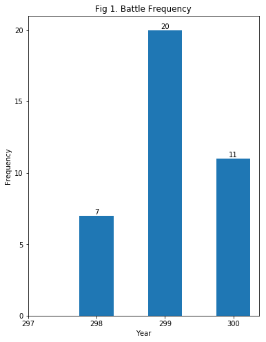

```python
#绘制每年发生战争次数的柱状图
year = df['year'].unique()
frequency = df.groupby('year')['year'].count().values
plt.figure(figsize = (6,8))
plt.bar(x = year, height = frequency, width = 0.5)
x_ticks = np.arange(297, 301, 1)
y_ticks = np.arange(0, 21, 5)
plt.xticks(x_ticks)
plt.yticks(y_ticks)
for a,b in zip(year, frequency):
    plt.text(a, b, b, ha='center', va= 'bottom')
plt.title('Fig 1. Battle Frequency')
plt.xlabel('Year')
plt.ylabel('Frequency')
plt.show;
```

由Fig 1可知，五王之战跨时三年，战争共计38场，主要集中在第二年。

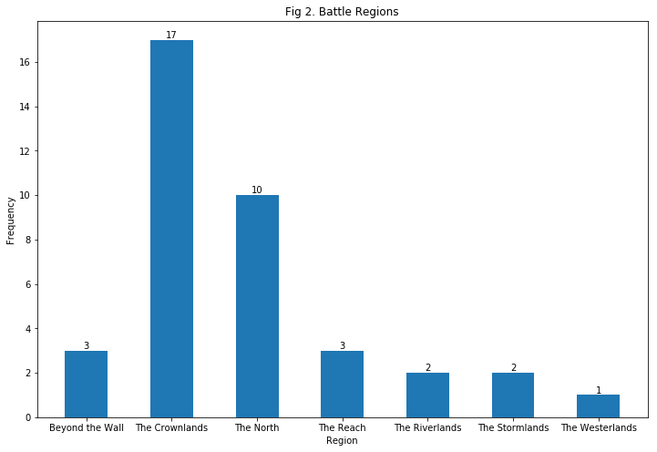

```python
#绘制每个区域发生战争次数的柱状图
region = df['region'].unique()
frequency = df.groupby('region')['region'].count().values
plt.figure(figsize = (12,8))
plt.bar(x = region, height = frequency, width = 0.5)
for a,b in zip(region, frequency):
    plt.text(a, b, b, ha='center', va= 'bottom')
plt.title('Fig 2. Battle Regions')
plt.xlabel('Region')
plt.ylabel('Frequency')
plt.show;
```

```python
#pivot table展示战争发生在各个国王之间的次数
df['count'] = 1
pd.pivot_table(df,index='attacker_king',columns = 'defender_king', values='count',aggfunc=np.sum)
```

| defender_king attacker_king | Balon/Euron Greyjoy | Joffrey/Tommen Baratheon | Mance Rayder | Renly Baratheon | Robb Stark | Stannis Baratheon |
| --- | --- | --- | --- | --- | --- | --- |
| Balon/Euron Greyjoy | 1.0 | 2.0 | NaN | NaN | 4.0 | NaN |
| Joffrey/Tommen Baratheon | 1.0 | NaN | NaN | NaN | 10.0 | 2.0 |
| Robb Stark | 1.0 | 9.0 | NaN | NaN | NaN | NaN |
| Stannis Baratheon | 1.0 | 2.0 | 1.0 | 1.0 | NaN | NaN |

由此Pivot Table可知，五王之战主要发生在Joffrey/Tommen Baratheon和Robb Stark之间，且两者互相攻击居多，其中：Joffrey/Tommen Baratheon进攻Robb Stark 10次，Robb Stark进攻Joffrey/Tommen Baratheon 9次。

**2.影响战争胜负的因素有那些？**

[figure not shown]

```python
#绘制战争发动方胜负次数的柱状图
attacker_outcome = df[df['attacker_outcome'].notnull()]['attacker_outcome'].unique()
frequency = df.groupby('attacker_outcome')['attacker_outcome'].count().values
plt.figure(figsize = (4,6))
plt.bar(x = attacker_outcome, height = frequency, width = 0.5)
for a,b in zip(attacker_outcome, frequency):
    plt.text(a, b, b, ha='center', va= 'bottom')
plt.title('Fig 3. Attacker Outcome')
plt.xlabel('Attacker Outcome')
plt.ylabel('Frequency')
plt.show;
```

```python
#了解战争类型
battle_type = df[df['battle_type'].notnull()]['battle_type'].unique()
print(battle_type)
frequency = df.groupby(['battle_type', 'attacker_outcome'])
frequency.size()
```

```
['pitched battle' 'ambush' 'siege' 'razing']
```

```
battle_type     attacker_outcome
ambush          win                 10
pitched battle  loss                 4
                win                 10
razing          win                  2
siege           loss                 1
                win                 10
dtype: int64
```

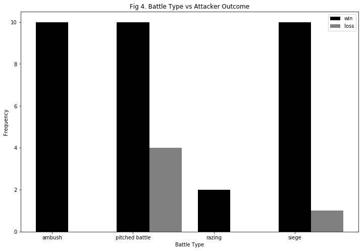

```python
#绘制战争类型与胜负关系的柱状图
battle_type = ['ambush', 'pitched battle', 'razing', 'siege']
#提取各类型战争输赢的次数，此处应该由我不知道的函数提取
win = [10, 10, 2, 10]
loss = [0, 4, 0, 1]
index = np.arange(len(win))
width = 0.4
plt.figure(figsize = (12, 8))
plt.bar(x = index, height = win, width = width, label = 'win',tick_label = battle_type,color = 'black')
plt.bar(x = index + width, height = loss, width = width, label = 'loss', color = 'grey')
plt.title('Fig 4. Battle Type vs Attacker Outcome')
plt.xlabel('Battle Type')
plt.ylabel('Frequency')
plt.legend()
plt.show();
```

```python
#删除attacker_size，defender_size和attacker_outcome列中有缺失数据的样本
battle_size_all = df[['attacker_size', 'defender_size', 'attacker_outcome']]
battle_size = battle_size_all.dropna(axis = 0, how = 'any')
battle_size.info()
```

```
<class 'pandas.core.frame.DataFrame'>
Int64Index: 15 entries, 0 to 30
Data columns (total 3 columns):
attacker_size       15 non-null float64
defender_size       15 non-null float64
attacker_outcome    15 non-null object
dtypes: float64(2), object(1)
memory usage: 480.0+ bytes
```

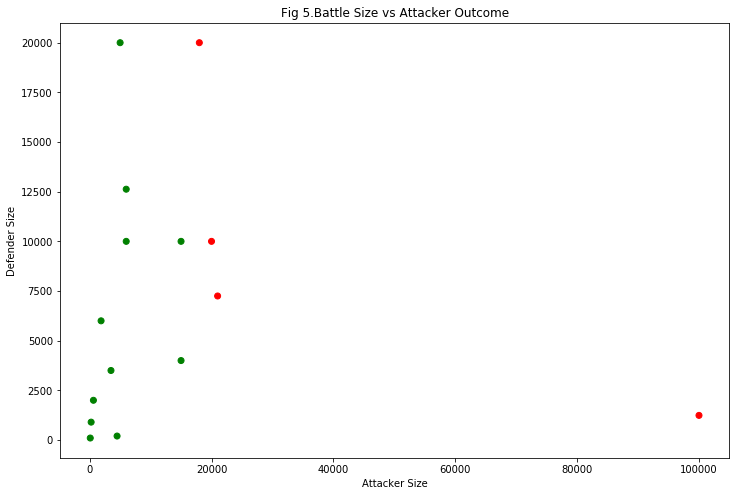

```python
#绘制攻防双方兵力与战争胜负关系的散点图
colorList = []
for i in battle_size['attacker_outcome']:
    if i == 'win':
        colorList.append('green')
    else:
        colorList.append('red')
y_axis = np.arange(0, battle_size['defender_size'].max())
x_axis = np.arange(0, battle_size['defender_size'].max())
plt.figure(figsize = (12, 8))
plt.scatter(battle_size['attacker_size'], battle_size['defender_size'], color = colorList)
plt.title('Fig 5.Battle Size vs Attacker Outcome')
plt.xlabel('Attacker Size')
plt.ylabel('Defender Size')
plt.show()
```

## 得出结论

参战国主要发生在Joffrey/Tommen Baratheon和Robb Stark之间，且两者互相攻击居多，这两个国王互相攻击的次数加起来为19次，占五王之战一半的战争数量。

发动战争方的胜率为86%；战争类型对胜负有一定影响：ambush战和razing战的胜率为100%；攻防双方的兵力与战争胜负无显著相关性。

## 反思

该数据集的部分数据缺失较多，在研究攻防双方兵力对战争胜负的影响时，不得不删除23个数据，使得样本仅剩15个，使分析结果的说服力有所减弱。

如果能获悉重要人物的被捕和死亡是对进攻方而言还是对防守方而言，可能会对研究胜负因素有一定帮助。